# Plots with ggplot2 are better plots!

# Recomended packages

```r
install.packages("reshape2", "cowplot", "ggrepel")
```

# Example dataset: Temperature in Barcelona (1780-2017)

## Data

We are going to use a dataset from [Servei Meteorològic de Catalunya](http://www.meteo.cat/wpweb/climatologia/serveis-i-dades-climatiques/serie-climatica-historica-de-barcelona/) describing the mean temperature per month from 1780 to 2017.[^1].

|  | month | year | temperature | season |
| --- | --- | --- | --- | --- |
| 1 | April | 1780 | 11.4 | Spring |
| 2 | April | 1781 | 13.7 | Spring |
| 3 | April | 1782 | 10.5 | Spring |
| 4 | April | 1783 | 12.4 | Spring |
| 5 | April | 1784 | 10.7 | Spring |
| 6 | April | 1785 | 11.0 | Spring |

## Average temperature per month

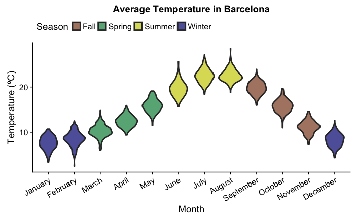

## Correlation between temperatures

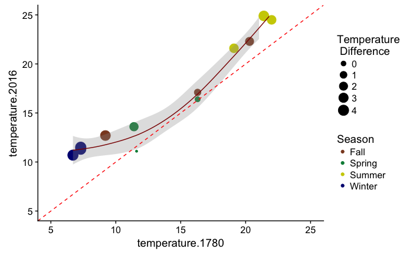

## Distribution of temperatures

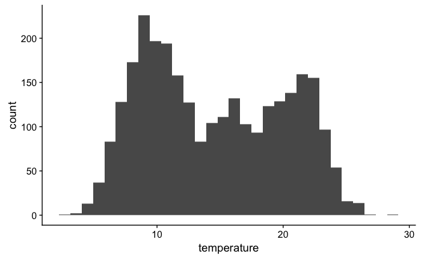

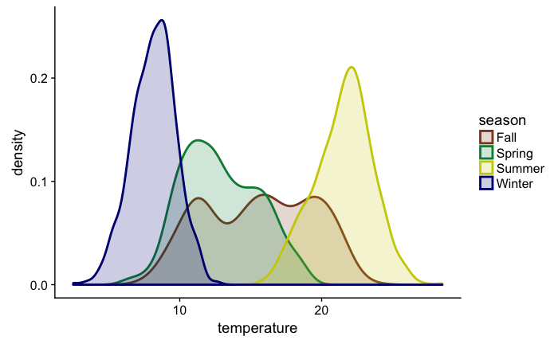

# Your turn! ChickWeight dataset

## Data

Load the dataset using `data("ChickWeight")` and explore the data with `View(ChickWeight)`. The description of the column values can be found typing `?ChickWeight`

## Exercise: Distributions

### Plot a histogram of weight distributions, faceting according to the Diet.

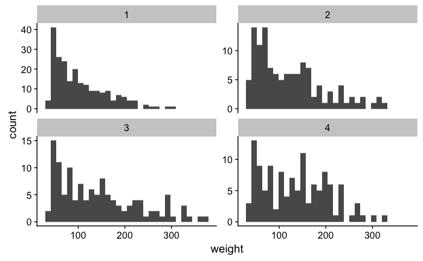

### Use geom_density to plot the density of weights coloring by Diet, and faceting by Time.

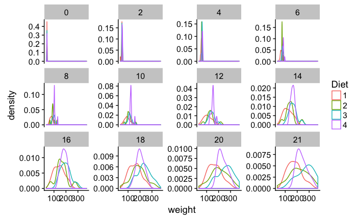

## Exercise: Boxplots

### Plot a boxplot of ChickWeight were x is Time and y is Weight.

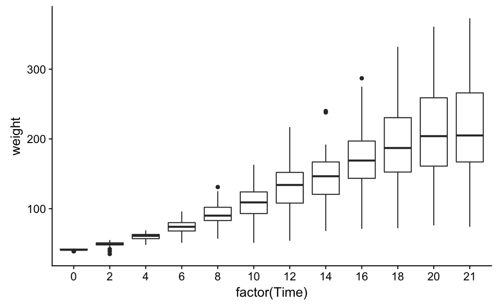

### Using the last boxplot, color groups according to the Diet.

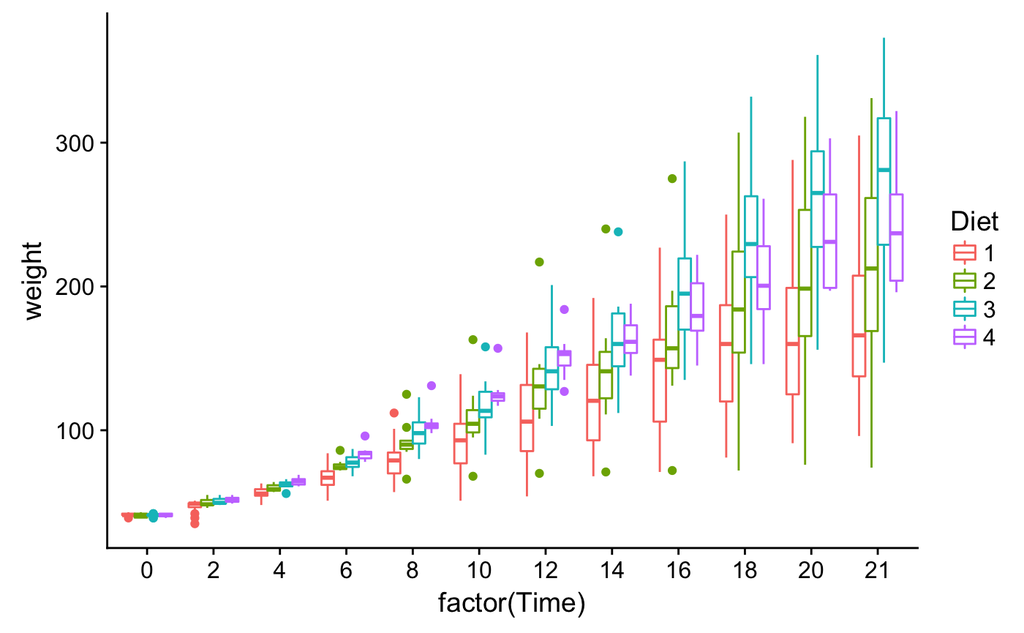

## Exercise: Correlations

### Compare with a scatterplot the weigth of the chickens the first day (Time=0) and the last day (Time=21). Color the points according to the Diet

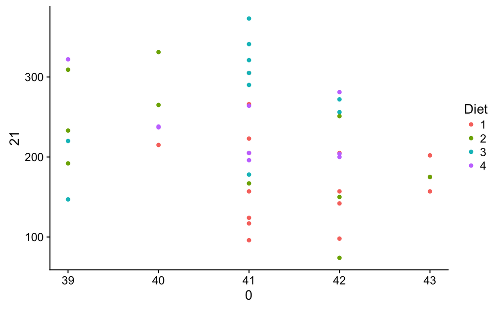

# Your turn! If you have things you want me to explain or to try you can ask!

[^1]: Prohom M, Barriendos, Aguilar E, Ripoll R (2012): Recuperación y análisis de la serie de temperatura diaria de Barcelona, 1780-2011. Cambio Climático. Extremos e Impactos, Asociación Española de Climatología, Serie A, Vol. 8, 207–217